# R - Introducción

### Trabajando con R

En los ejemplos de R anteriores se ha interactuado directamente con la consola. Todo lo que sigue a continuación podría seguir haciéndose de la misma manera. Sin embargo,

> es muy recomendable trabajar con **[scripts](https://campusvirtual.uclm.es/pluginfile.php/3179087/mod_resource/content/1/R-Intro.html#Scripts)**, `File > New File > R Script`.

Se identifican por su extensión .R. RStudio permite ejecutar línea a línea cada script, situándose en cualquier parte de la línea que se quiere ejecutar y pulsando `Ctrl + Enter` (también se pueden ejecutar varias líneas, pero entonces hay que seleccionarlas).

Cabe la opción de guardar en un script el Historial de sentencias/instrucciones ejecutadas en la consola. Como se ha mencionado anteriormente, están en la pestaña `History`.

- *Nota*: La opción *ideal*, algo más sofisticada y a la vez cómoda, es trabajar usando la opción *Proyectos* de R.  
  Si se tiene interés en ello se puede consultar la práctica [Crear un proyecto en RStudio](http://emilio.lcano.com/b/adr/_book/ch-intro.html#practica-1.4-crear-un-proyecto-en-rstudio) del exprofesor de la UCLM y gran experto en R Emilio López Cano.  
  Si no se usa esta opción, es muy recomendable separar cada proyecto en carpetas o directorios distintos.

R trabaja con un **directorio activo**, donde (si no se le indica otra cosa) [guarda/lee](https://campusvirtual.uclm.es/pluginfile.php/3179087/mod_resource/content/1/R-Intro.html#Leyendo) los ficheros de datos, scripts, etc.

```r
getwd() # working directory (ubicación)
setwd("...dirección de la carpeta...") # para establecer como WD el directorio indicado
```

¡Ojo! que en R se usa / para especificar el anidamiento de carpetas (mientras que en Windows se usa \).  
Lo mejor, para evitar equívocos en el nombre del directorio, es usar la pestaña `Files` (`More` `>` `Set As Working Directory`) o vía menú `Session` `>` `Set Working Directory` `>` `Choose Directory...`

**Sintaxis:**

- `Mm`$\neq$`mm`: R es **case sensitive**. Sensible a las mayúsculas. Diferencia entre MAYÚSCULAS y minúsculas. Puede llevar a *errores* “tontos”. ¡Mucho cuidado!
- `#` para incluir **comentarios**. R no ejecuta lo que vaya tras el símbolo almohadilla.
- `;` para separar varias expresiones/[funciones](https://campusvirtual.uclm.es/pluginfile.php/3179087/mod_resource/content/1/R-Intro.html#Funciones)/instrucciones en la misma línea de la consola/editor (script). Ahora bien, utilizar `;` dificulta la “lectura” del código.
- Sintaxis incompleta. En algunos casos R detecta que falta algo de sintaxis por lo que en la consola se muestra el símbolo `+` y el “sistema” se queda esperando

  ```r
  sqrt(144 #caso sencillo de sintaxis incompleta, le falta ")"
  ```

  Si se añade ), y se pulsa Enter el sistema ejecutará la sentencia sin problemas. Si se le proporciona algún símbolo no apropiado para esa sentencia dará error. ¡Ojo! porque puede ser que se añadan símbolos que sí tengan sentido, por ejemplo, si se añadiese “+1”, y seguiría esperando, sin dar error, hasta que se cerrase el paréntesis (o se abortase la operación, se cometiese un error sintáctico…).

**Mensajes de error/warning:**

R intenta no dar mensajes de error (¿robusto?). Esto es un arma de doble filo, ¿verdaderamente hace lo que yo quiero que haga?

```r
sqrt 144   # da un error
sqrt(-144) # aparece un warning
```

- ¡No confundir `Error` con `Warning`!  
  La diferencia en R es
  - con `Error`, R no ejecuta la sentencia.
  - con `Warning` se ejecuta, es un aviso sobre algún aspecto que puede estar equivocado.

### Primeros objetos

R es un lenguaje de programación que trabaja con **objetos**.

> Todas las *variables* son objetos pero no todos los objetos son variables.

Se va a comenzar por **declarar** y **asignar valores** a objetos. R utiliza como operador de asignación `<-` (preferentemente). Se pueden utilizar también `->` y `=` (éste último, no recomendable, por ser confundible con el operador relacional `==` que se verá más adelante).

> **`Nombre_de_objeto <- Valor`**

(si se deja un espacio antes y otro después de la “flecha” se tendrá una mejor “lectura” del código).

Para **Nombre_de_objeto** se pueden utilizar **letras**, **números** y los símbolos: ‘**.**’ y ’_’.

- *Recordatorio*: “case sensitive”.  
  *Consejo*: No usar acentos ni espacios (para compatibilidad de los scripts en otros ordenadores/sistemas).

Se aprovechan los siguientes ejemplos de *declaración* y *asignación de valores* para mostrar distintos **tipos** o **modos de almacenamiento** (`mode`) de objetos.

```r
x <- 144      # numeric
xx <- 2 + 3i  # complex (forma binómica a + bi)
y <- "blanco" # character. ¡Las comillas son indispensables!
z <- TRUE     # logical (TRUE se puede abreviar con T ¡Ojo al nombrar objetos!)
```

R, por defecto, *NO* muestra el valor de un objeto. Para mostrarlo se puede

- poner el nombre del objeto y ejecutar
- utilizar la [función](https://campusvirtual.uclm.es/pluginfile.php/3179087/mod_resource/content/1/R-Intro.html#Funciones) `print` o
- escribir la sentencia toda entre paréntesis: (…).

```r
x
```

```
## [1] 144
```

```r
print(x)
```

```
## [1] 144
```

```r
( j <- pi ) # Realiza la asignación y muestra el valor de j
```

```
## [1] 3.141593
```

```r
h <- pi     # Realiza la asignación, pero no muestra ninguna salida
#h - j
```

La última sentencia al llevar `#` no se ejecuta (no sólo sirve para comentarios). Y dicha sentencia serviría para comprobar (si devuelve cero) que se han realizado ambas asignaciones. Quizá algún lector se lo crea sin más, pero lo mejor es ejecutarlo para comprobarlo… ¡experimentar!  
Por cierto, por si quedan dudas, dicha sentencia `h - j` es una operación, no una asignación, y por ello sí muestra el resultado por pantalla al ejecutarse.  
Por otro lado, si se ejecuta `z - y` dará un error, debido al tipo de objetos que son…  
Lo dicho, lo mejor es interactuar con R para comprobar los resultados, confirmar las intuiciones, etc.

**Pestaña Environment**:  
Muestra los objetos almacenados en cada momento y (según la “vista”: List o Grid) da los valores… o el tipo…

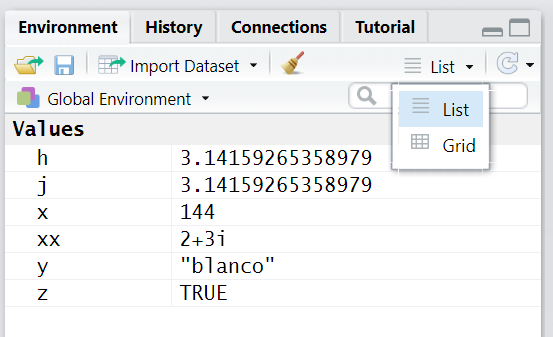

Figura 3. Pestaña Environment

También puede mostrarse por la consola un listado de los objetos creados, ejecutando `objects()` o `ls()` (así, tal cual, sin nada entre los paréntesis).  
Y cuando existen muchos objetos en el `Environment` se puede usar `ls` con el **[argumento](https://campusvirtual.uclm.es/pluginfile.php/3179087/mod_resource/content/1/R-Intro.html#Argumento)** `pattern` para obtener un listado de aquellos objetos cuyo nombre contiene el *patrón* especificado (también acudiendo a la “lupa” de la pestaña `Environment`).

```r
ls(pattern = "x")
```

```
## [1] "x"  "xx"
```

Si interesa borrar algún objeto (u objetos) se puede hacer de una manera muy intuitiva con el icono de la escoba (primero ha de seleccionarse el objeto(s) en la “vista” Grid). Si no se selecciona ningún objeto se borran ¡todos!  
También se pueden borrar por la consola (o script), de una forma más controlada, utilizando la función `rm`.

**Operadores:**

- **lógicos**: AND (`&`), OR (`|`), NOT (`!`).
- **relacionales**: igualdad, negación/distinto, …: `==, !=, >, >=, <, <=`.

```r
x == 12  # ¿Es x igual a 12?
```

```
## [1] FALSE
```

```r
sqrt(x) == 12
```

```
## [1] TRUE
```

```r
x == 12 | sqrt(x) == 12
```

```
## [1] TRUE
```

### Funciones y paquetes

Las **funciones** procesan los **[objetos](https://campusvirtual.uclm.es/pluginfile.php/3179087/mod_resource/content/1/R-Intro.html#Objetos)** (vectores y otros). Son módulos de código que facilitan los cálculos y las tareas. Se identifican mediante un nombre, llevan asociadas unos **argumentos** (los inputs de la función, elementos necesarios para el correcto desempeño de la función; se ponen entre paréntesis y separados por comas) y devuelven un **resultado** (que puede o no presentarse por pantalla).

Algunas funciones habituales del paquete `base`: `sum`, `length`, `mean`, `min`, `max`, `range`, …

```r
sqrt(-144 + 0i) # función: sqrt, argumento: dato/valor en este caso
sqrt(abs(-4)) # función: sqrt, argumento: otra función, abs, con su correspondiente argumento
log(100, base = 10) # función: log, argumentos: dato/valor y "base"
```

En la ayuda de cada función se definen los *argumentos* que pueden proporcionarse. Por norma general, es necesario introducirles al menos un argumento (aunque se acaban de ver funciones como `objects` y `ls` que no los necesitan). El creador/desarrollador de la función otorga a algunos argumentos valores por defecto, que pueden cambiarse, como se ha hecho con `base` en la función `log`. ¿Se había consultado ya el valor por defecto para `base`? (Si no, es ahora el momento: `?log`). No es necesario proporcionar todos los argumentos y se le pueden suministrar de diversas formas como se verá por ejemplo [aquí](https://campusvirtual.uclm.es/pluginfile.php/3179087/mod_resource/content/1/R-Intro.html#seq).

Es posible crear funciones, como se hará más adelante, que se definirá una función para obtener la moda estadística, o como puede verse [aquí](https://www.dummies.com/programming/r/how-to-create-a-function-in-r/).

Por último hay que mencionar que algunas funciones generan objetos de tipo *lista* compuestos de diversos **componentes** a los que se podrá acceder individualmente. Más adelante se verán varios ejemplos de *componentes de un objeto*, por ejemplo con la función `hist` que sirve para generar un objeto de clase *histogram* que es a su vez una *lista*. La lista contiene tanto el “gráfico” (histograma) correspondiente (más bien la información para que R lo pueda representar), como diversa información: los intervalos para realizar el gráfico, las frecuencias de cada intervalo, etc.

Existen muchísimas funciones definidas en los numerosísimos **paquetes (packages)** que tiene R: https://cran.r-project.org/web/packages/  
A día de hoy (2021-02-03) hay 17070.

- *Nota:* algunas funciones están “repetidas/redefinidas” en varios paquetes.

**Instalación de paquetes**

Al arrancar R se cargan por defecto en la sesión el paquete `base` y otros:

```r
(.packages())
```

```
## [1] "stats"     "graphics"  "grDevices" "utils"     "datasets"  "methods"
## [7] "base"
```

Pudiendo así utilizar las funciones más habituales (y algunos datasets).

Para poder usar una función, dataset, etc. de un **paquete** no básico, de los que no vienen con la instalación por defecto, primero hay que instalar el paquete. Se puede utilizar `install.packages("...")` o acudir al menú `Tools > Install Packages...`, o más fácilmente, a través de la pestaña `Packages` de RStudio.

> La **instalación** de un paquete **sólo** es necesaria hacerla **una vez** (por versión).  
> Pero hay que **cargar** el paquete **en cada sesión de trabajo** (en la que se quiera usar).

```r
install.packages("e1071") # Descarga e instala el paquete
```

- *Nota:* Algunos paquetes requieren de otros que tampoco se encuentran almacenados en tu ordenador. R los instalará junto con el paquete solicitado.

Para **cargar** un paquete ya instalado se puede usar la función `library`. También (pero no sería reproducible) se puede activar la casilla correspondiente en la pestaña `Packages` de RStudio (que ejecuta dicha función).

- *Recomendación*: NO incluir en los scripts sentencias de instalación de paquetes.  
  SÍ incluir la(s) sentencia(s) de carga de paquete(s).

```r
library(e1071)
```

Para consultar la ayuda del paquete, listado de funciones incluidas, autores, web, etc. Se puede acudir a la pestaña Packages y pinchar sobre el nombre del paquete. Si se quiere hacer desde la consola: `library(help = "e1071")`

Por último las siguientes sentencias pueden ser útiles en determinados momentos

```r
library()     # Muestra (en el editor) los paquetes instalados en tu ordenador
sessionInfo() # Muestra información de la sesión actual (incluidos paquetes cargados)
```

La última sentencia puede ser muy útil incorporarla en los informes que se obtengan con R, para reproducibilidad y transparencia de resultados.

## 1.3 Introducción de datos con R

R dispone de varias *estructuras* para almacenar datos, y numerosas funciones para procesarlos. Las estructuras de datos más importantes son:

- **Vector:** secuencia de datos ordenados. Se verán ejemplos a continuación.
- **Matriz:** estructura bidimensional de datos. Ejemplos [aquí](https://campusvirtual.uclm.es/pluginfile.php/3179087/mod_resource/content/1/R-Intro.html#Matrices)
- **Array:** estructura de datos que admite más de dos dimensiones. Ejemplos [aquí](https://campusvirtual.uclm.es/pluginfile.php/3179087/mod_resource/content/1/R-Intro.html#Matrices)
- **Data Frame:** marco o tabla de datos, de estructura **rectangular**. *Estructura por **excelencia** en R*. Organizado en columnas y filas.  
  Columna = Variable: Cada columna se identifica (contiene) una variable.  
  Fila = Individuo…: Cada fila corresponde a los datos de la(s) variable(s) de un individuo/elemento/observación.  
  Ejemplos [aquí](https://campusvirtual.uclm.es/pluginfile.php/3179087/mod_resource/content/1/R-Intro.html#DataFrame)
- **Lista:** los componentes de una lista pueden ser de todos y cada uno de los tipos anteriores, incluso listas. Un ejemplo (el ya mencionado del histograma) se puede ver [aquí](https://campusvirtual.uclm.es/pluginfile.php/3179087/mod_resource/content/1/R-Intro.html#ejplolista).

A su vez, como ya se ha mencionado, los datos puede ser de distintos tipos (`mode`) **numérico, complejo, carácter, lógico…** (se ha definido un objeto de cada tipo [anteriormente](https://campusvirtual.uclm.es/pluginfile.php/3179087/mod_resource/content/1/R-Intro.html#tipos)). Así se tienen estructuras de datos de distintos tipos, bastando, por ejemplo, que haya un dato complejo entre varios numéricos para que todo el vector/matriz/array sea complejo, o que haya un dato de tipo carácter entre varios numéricos o complejos para que todo el vector/matriz/array sea carácter… Obviamente los data frames pueden ser una mezcla de “tipos”, al estar compuestos de vectores que pueden ser de distinto tipo. Y lo mismo las listas.

### Primeros Vectores

Se crearán primero **vectores** numéricos de datos, concretamente creando secuencias de valores:

```r
x1 <- 1:10    # lo esperable ¿no?
x2 <- 10:-10  # curioso!
```

También las funciones `seq` y `rep` permiten crear secuencias y valores repetidos.

```r
rep(0.5, times = 10)
rep(0.5, 10)    # ¡Ojo, cuando no se ponen los nombres de los argumentos!
seq(from = 1, to = 10, by = 0.1)
seq(1, 10, 0.1) # ¡Ojo, con el orden!
```

Para introducir valores (*a mano*) se puede usar la función **combinación** `c` (`?c`), que creará un vector

```r
x <- c(12, 43, 21, 65, 23, 61, 32)
```

- Por el comentario anterior sobre el tipo (`mode`):

  ```r
  datos <- c(144, -144, -144 + 0i)
  mode(datos); sqrt(datos)
  ```

  ```
  ## [1] "complex"
  ```

  ```
  ## [1] 12+ 0i  0+12i  0+12i
  ```

- Otra opción es usar la función `scan`, introduciendo uno a uno los valores seguidos de un `Enter`, o separándolos por un espacio, y terminando con un doble `Enter`. (Por esto último del doble Enter se desaconseja totalmente el uso de `scan` en los scripts).

  ```r
  x <- scan()
  # Se introducen manualmente los datos seguidos de Enter o separándolos por espacios
  12 43 21 65 23 61 32
  # Se "cierra" el scan con un doble Enter
  ```

Si hubiese interés, por alguna razón, en **etiquetar** los valores del vector, se puede utilizar la función `names`, que permitirá buscar dentro de estos vectores utilizando el nombre asignado. Por ejemplo:

```r
names(x) <- paste0("d", 1:7)
x
```

```
## d1 d2 d3 d4 d5 d6 d7
## 12 43 21 65 23 61 32
```

```r
names(x) <- c("Lun", "Mar", "Mie", "Jue", "Vie", "Sab", "Dom")
x
```

```
## Lun Mar Mie Jue Vie Sab Dom
##  12  43  21  65  23  61  32
```

**Ejemplo**

La “shelf life” de una bebida carbonatada es una variable de interés. Se seleccionan 10 botellas al azar y se obtienen los siguientes resultados (en días).

```r
ShelfLife <- c(108, 124, 124, 106, 115, 138, 163, 159, 134, 139)
```

Se pueden realizar múltiples **operaciones aritméticas, lógicas, etc.** con este vector de datos numéricos.

> ¡Ojo! Las operaciones son vectorizadas… Elemento a elemento (¡si se puede!, es decir, si las longitudes “cuadran”)

```r
( Semanas <- ShelfLife / 7 )
ShelfLife > 120            # ¿Qué valores son mayores de 120? Pero ¿qué devuelve?
which(ShelfLife > 120)     # ¿Y ahora qué devuelve?... Índices (posiciones)
ShelfLife[ShelfLife > 120]
```

En la última sentencia se ha realizado, mediante el uso de los corchetes `[]`, una selección de valores del vector usando **indexación lógica** (una buena potencialidad de R). Se trata de utilizar condiciones para filtrar/seleccionar sólo algunos elementos del vector.  
Las siguientes sentencias servirán para clarificar cómo actúa la indexación lógica.

```r
ShelfLife[1]      # ¿primer dato?
ShelfLife[2:6]    # ...
ShelfLife[c(1,4)] # ...
ShelfLife[-3]     # No quita tres datos, quita ...
ShelfLife[ShelfLife > 120 & ShelfLife < 140]
x["Mar"]          # Aprovechando el "name"
```

Por último… ¿qué suma se quiere?

```r
sum(ShelfLife > 120)
sum(ShelfLife[ShelfLife > 120])
```

Y otras funciones interesantes…

```r
sort(ShelfLife)
cumsum(ShelfLife)
diff(ShelfLife)
```

¿Ha notado que el resultado de `diff` contiene un dato menos que el vector proporcionado? ¿por qué?

Si se tienen más datos de la variable se pueden añadir a los existentes

```r
#ShelfLife.comb <- c(ShelfLife, 143, 98, 121, 101, 132) # Directamente
ShelfLife2 <- c(143, 98, 121, 101, 132) # Por si interesa tenerlos aparte
( ShelfLife.comb <- c(ShelfLife, ShelfLife2) )
```

```
##  [1] 108 124 124 106 115 138 163 159 134 139 143  98 121 101 132
```

O hacer alguna operación con ellos, como por ejemplo el porcentaje de variación respecto de los primeros datos (si tuviese sentido):

```r
( porcent.variac <- ShelfLife2/ShelfLife )
round(porcent.variac, digits = 2)
paste(round(porcent.variac, digits = 2)*100, "%")
```

### Definiendo matrices y arrays

Como ya se ha señalado, las **matrices** son organizaciones bidimensionales de datos.  
Los **arrays** pueden ser estructuras multidimensionales.

Para transformar un vector en una matriz o un array, se pueden usar las instrucciones `matrix` y `array`.

```r
x <- 1:16
x1 <- matrix(x, nrow = 4, ncol = 4)
x2 <- matrix(x, 4, 4, byrow = TRUE)
x1[4, 1]; x2[1, 4]
dim(x1); dim(x2)
x1 * x2
x1 %*% x2
```

¿Qué diferencia habrá entre el operador `*` y el operador `%*%`?… `help("*")`

```r
x3 <- array(x, dim = c(4, 2, 2))
x4 <- array(x, dim = c(2, 2, 2, 2))
```

También se pueden crear matrices a partir de vectores utilizando `rbind` o `cbind`. Con `rbind` se crea una matriz con los vectores dispuestos en filas (rows), mientras que con `cbind` se disponen en columnas.

```r
x1b <- cbind(ShelfLife.comb, ShelfLife2) # ¡Ojo!  "reciclaje" del vector corto
                                         # (véase "recycled" en la ayuda de cbind)
```

### Data Frame: la estructura estrella

El **marco o tabla de datos, data frame,** *rectangular* es el conjunto de datos más común en estadística. Los datos estadísticos son observaciones de una o varias variables sobre varios individuos. Las variables, que pueden ser de distinto tipo, se organizan en columnas, mientras que los casos o individuos ocupan cada uno de ellos una fila distinta.

La forma más sencilla de crear una tabla de datos es con la función `data.frame` aplicada a vectores (de la misma longitud). Cada vector será una columna del nuevo marco de datos.

**Ejemplo**

Se seleccionaron muestras de tres tipos distintos de cables de acero, determinándose el límite de fatiga (MPa). Los tres primeros valores de fatiga son del modelo A23, los tres siguientes del modelo Zb14 y los tres últimos del modelo F2z.

```r
lim.fatiga <- c(371, 384, 392, 350, 354, 359, 361, 364, 366)
tipo.acero <- c(rep("A23", 3), rep("Zb14", 3), rep("F2z", 3))
( acero <- data.frame(lim.fatiga, tipo.acero) )
dim(acero)    # Esta información también está "disponible" en Environment
names(acero)  # Esta información también está "disponible" en Environment
acero[1, 1]
acero[6, 2]
acero[1:5, 1]
acero[1:5, 2]
acero[1:5, ]
```

- *Nota:* Cuando se muestra/accede a una columna de un data frame con la sintaxis
  - `nombre[i]` el resultado es un nuevo data frame.
  - `nombre[[i]]` el resultado es un vector.

#### Ejercicio 1

Se ha medido el tiempo de reparación (en horas) y el coste (en euros) de un conjunto de instrumentos electrónicos. Los tiempos de reparación de varios instrumentos elegidos al azar es el siguiente:

159, 280, 101, 212, 224, 379, 179, 264

Y sus costes:

23.12, 43.15, 34.95, 54.23, 65.65, 22.45, 45.78, 87.65

Escriba el código necesario para:

- Crear un vector con los tiempos de reparación y otro con los costes.
- Utilizar las funciones `min` y `max` para identificar el tiempo de reparación más alto y más bajo.
- Identificar las posiciones en el vector que ocupan los costes de reparación mínimo y máximo.  
  *Obs*: Existen diversas alternativas. Si se decanta por evaluar la condición de igualdad recuerde que el operador es `==` (no confundir con `=`).
- Transformar el vector de tiempos en un nuevo vector en el que los tiempos de reparación se expresen en días.
- Eliminar de dicho vector los valores mínimo y máximo.  
  *Obs*: para eliminar más de un elemento de un vector, además de usar el signo `-` es necesario “combinar” `vector[c(-i, -j)]`.
- Crear un nuevo data frame llamado `reparaciones` que contenga los datos de tiempo y costes de todos los instrumentos.
- ¿Cuáles son los nombres de las columnas del nuevo data frame?
- Acceder a los datos de reparaciones de los instrumentos impares.  
  *Ayuda*: por ejemplo `seq(from = ..., to = ..., by = ...)`.

### Data frames en R

Muchos paquetes de R incluyen conjuntos de datos de prueba, son *data frames* que son accesibles y con los que se puede trabajar directamente (si se ha cargado el paquete que los contiene). Para conocer qué conjuntos de datos se encuentran disponibles en nuestra sesión de R, basta con ejecutar `data()`.

Se va a estudiar, por ejemplo, el conjunto de datos `PlantGrowth`.

```r
PlantGrowth
help(PlantGrowth)
dim(PlantGrowth)
nrow(PlantGrowth)
ncol(PlantGrowth)
names(PlantGrowth)
rownames(PlantGrowth)
```

```r
summary(PlantGrowth)
```

```
##      weight       group
##  Min.   :3.590   ctrl:10
##  1st Qu.:4.550   trt1:10
##  Median :5.155   trt2:10
##  Mean   :5.073
##  3rd Qu.:5.530
##  Max.   :6.310
```

Como se aprecia, en función del tipo de variable, el `summary` devuelve *resúmenes* distintos. En la parte de Estadística descriptiva se explicarán en detalle estos *resúmenes*.

Para “acceder” ([indexación](https://campusvirtual.uclm.es/pluginfile.php/3179087/mod_resource/content/1/R-Intro.html#Indexaci%C3%B3n)) a las variables del data frame `PlantGrowth` se puede usar:

```r
PlantGrowth[, 1]
PlantGrowth[1]
PlantGrowth[[1]]
PlantGrowth$weight
PlantGrowth[, 2]
PlantGrowth$group
```

- *Nótese* el uso del `$`+nombre de la variable para obtener los datos de dicha variable.  
  Sin duda, es la manera más “clara”, y de menores equívocos, para incluir en un código/script.

#### Ejercicio 2

Realice el mismo estudio acerca del contenido del data frame `ToothGrowth`

Intente explicar cuáles son los resultados de las siguientes instrucciones:

`ToothGrowth[1:10, ]`  
`ToothGrowth$supp == "VC"`  
`ToothGrowth[ToothGrowth$supp == "VC", ]`  
`ToothGrowth[ToothGrowth$supp != "VC", ]`  
`ToothGrowth[ToothGrowth$len>10, 2]`  
`ToothGrowth[ToothGrowth$len>10 & ToothGrowth$dose == 0.5, 2]`  
`which(ToothGrowth$len>10 & ToothGrowth$dose == 0.5)`

### Leyendo/Guardando Ficheros

En R se pueden manejar diversos **formatos** de ficheros.

**.Rdata**:  
Son los ficheros propios de R, junto con los ficheros `.rds`. La manera (rápida y fácil) de cargar ficheros `.Rdata`, es visualizarlos en la pestaña `Files` y hacer clic sobre ellos. Se abrirá un cuadro de diálogo preguntando si tales datos quieren incorporarse al `Environment`.  
No obstante, para la reproducibilidad de scripts es conveniente utilizar la función `load`.

```r
load("____Nombre_de_fichero____.Rdata")
```

- *Recordatorio*: R lee, y guarda, los ficheros desde el llamado *[directorio de trabajo activo](https://campusvirtual.uclm.es/pluginfile.php/3179087/mod_resource/content/1/R-Intro.html#workingdirectory)*.  
  No obstante, para leer y cargar un fichero desde un directorio distinto del de trabajo se puede añadir la ruta de la carpeta delante del nombre del fichero. *Si se hace a través de la pestaña `Files` se podrá obtener el código (pestaña `History`) y copiarlo en el script*.

**Otros formatos de datos**:  
R también permite leer/importar datos de diferentes tipos y fuentes: **.txt, .csv, .xls o .xlsx -excel-, .sav -spss-…** La mejor opción es acudir a “Import Dataset” de la pestaña `Environment` de RStudio. Permitirá, mediante una serie de menús/ventanas previsualizar y configurar la importación, mostrando el código necesario para hacerlo (incluso si se debe utilizar algún paquete específico para la importación). Dicho código se podría ejecutar directamente o utilizarlo para un script. Otras posibilidades son usar directamente las funciones del paquete `base` o las de otros paquetes apropiados (que como se ha dicho, para poder utilizarlos, hay que instalar *1* vez, y cargar *en cada sesión*).

La función más básica para realizar la lectura de un fichero en formato **CSV** (comma separated values), uno de los más comunes para compartir datos, es `read.table`. En http://openmv.net/file/bioreactor-yields.csv encontrará y podrá descargar el fichero de *Producción de Biorreactor* que se lee/carga en R con la siguiente sentencia:

```r
bioreactor <- read.table("bioreactor-yields.csv", header = T, sep = ",")
```

- *Recordatorio*: `T` es la abreviación de `TRUE`.

R también permite **cargar datos almacenados en la red**:

```r
bioreactor <- read.table("http://openmv.net/file/bioreactor-yields.csv", header = T, sep = ",")
```

Para cargar datos desde ficheros **Excel**, existe la posibilidad de guardar en el propio Excel el fichero en el citado formato CSV: Archivo > Guardar Como… (en Excel!)

Otra opción es seleccionar y copiar en el **portapapeles** los datos a importar. Descargue el fichero PaisesEuropeos.xlsx disponible en moodle. Ábralo en excel, seleccione los datos que desee y copie en el portapapeles. Después ejecute:

```r
read.table("clipboard", header = T)
```

Aunque la opción más segura, como se ha mencionado, es utilizar la opción `Import Dataset` de la pestaña `Environment`.

- Más sobre importar ficheros desde Excel: http://blog.datacamp.com/r-tutorial-read-excel-into-r/

**Guardando**:  
Para **guardar** un conjunto/vector de datos como `ShelfLife` en un fichero .Rdata basta visualizarlo en la pestaña `Environment`, marcarlo (“vista” Grid) y pinchar en el icono de guardar. Habrá que elegir el directorio donde guardarlo y darle un nombre al fichero.  
No obstante, como se ha comentado antes, para la reproducibilidad de scripts es conveniente utilizar la función `save` o alguna de las variantes de `write` si se quiere guardar en un formato distinto: `write.table`, `write.csv`, `write.csv2`.

```r
save(ShelfLife, file = "ficheroShelfLife.Rdata")
load("ficheroShelfLife.Rdata")
```

`save.image()` guarda todo el contenido del espacio de trabajo actual (workspace, las variables y data frames que se ven en la pestaña `Environment`) en un fichero genérico llamado `.RData` en el directorio activo.

Si sólo se quiere guardar un objeto de R se puede guardar con la extensión `.rds` utilizando la función

```r
?saveRDS
```

#### Ejercicio 3

Escriba los comandos necesarios para realizar las siguientes acciones:

- Cargar el fichero [ChedarCheese](http://openmv.net/file/cheddar-cheese.csv) que puede encontrar en la dirección http://openmv.net/file/cheddar-cheese.csv
- Cargar el fichero Cojinetes.xlsx disponible en moodle.
- Grabar el espacio de trabajo actual con el nombre “ej3.Rdata”.
- Ejecute la sentencia: `rm(list=ls(all=TRUE))` que borra todo el espacio de trabajo. Cierre la sesión de R y abra una nueva donde cargue el workspace “ej3.Rdata” usando la función `load`.

### Valores especiales: `NA`…

En conjuntos de datos reales suelen existir valores **perdidos** o que faltan, individuos o sujetos para los que se desconoce el valor de una (o varias) variable(s). Habitualmente estos valores se codifican de maneras muy variadas: con un “.”, con el código “999”… R utiliza la expresión `NA`, “Not Available / Missing values”.

```r
x <- c(1, 2, 3, 2, 1, 3, NA, 4, 2, 3, NA, 9, NA)
is.na(x)
sum(x)
sum(x, na.rm = T)
sum(is.na(x))
```

¿Qué diferencias hay entre las tres ejecuciones de la función `sum`?

- *Nota*: cualquier operación en la que haya algún valor `NA` dará como resultado `NA` (como indican acertadamente Grolemund y Wickham, es [“contagioso”](https://r4ds.had.co.nz/transform.html#missing-values)) .  
  El [*argumento*](https://campusvirtual.uclm.es/pluginfile.php/3179087/mod_resource/content/1/R-Intro.html#Argumento) `na.rm = TRUE` en aquellas *funciones* que lo admitan, como `sum`, `mean` … Operará con los datos válidos ignorando los valores `NA`.

A la hora de importar un fichero se puede especificar a R cómo se han codificado los valores perdidos.

```r
read.table("__Nombre_fichero__.csv", header = T, sep = ",", na.strings = c(".", "999"))
```

`complete.cases` permite descartar individuos con datos perdidos.

```r
x <- c(7, 8, NA, 9, 7, 6, 9, 8, 12, 5)
y <- c(6, 1, 8, 5, 2, 9, NA, 2, 5, 7)
datos <- data.frame(x, y)
datos
complete.cases(datos)
datos[complete.cases(datos), ]
```

**Otros valores especiales:**

| value | definition |
| --- | --- |
| NaN | Not a Number (ex: 0/0) |
| NULL | Sin valor |
| Inf | Infinito |

- A veces, hay cálculos que dan como resultado expresiones no numéricas, que R representa como `NaN`. También puede suceder cuando no está bien definido el tipo numérico del objeto.
- No confundir `NULL` con `NA`. Los valores `NULL` son ignorados en las operaciones (los `NA` se acaba de decir que trastocan los resultados, pero también se ha dicho como pueden ignorarse).